# Programowanie w R: Projekt - Karłowacenie śledzi

Wojciech Marciniak 141274

2022-12-12

# 1 Raport

Niniejszy raport przedstawia analizę danych dotyczących połowu śledzi i próbuje odpowiedzieć na pytanie co jest przyczyną zaobserwowanego karłowacenia śledzi oceanicznych wyławianych w Europie na przestrzeni ostatnich lat. Przeprowadzona analiza okazała się bardzo trudna za względu na niestandardową strukturę danych i przez to tworzenie modeli okazało się bardzo skomplikowane. Sama obserwacja wielkości śledzia na podstawie tych danych na przestrzeni lat jest również niemożliwa. Mimo to udało się ustalić, że największy wpływ na rozmiar śledzi ma prawdopodobnie zmieniająca się temperatura nad powierzchnią wody, jak i natężenie połowów.

# 2 Wykorzystane biblioteki

```r
library(knitr)
library(dplyr)
library(caret)
library(kableExtra)
library(tidyr)
library(tidyverse)
library(ggplot2)
library(plotly)
library(gganimate)
library(corrplot)
library(ggpubr)
library(vtable)
```

# 3 Zapewnienie powtarzalności wyników przy każdym uruchomieniu

Aby zapewnić powtarzalność rezultatów podczas kolejnych wykonań skryptu, ziarno zostaje ustawione na konkretną stałą.

```r
set.seed(23)
```

# 4 Wczytanie danych z pliku

Dane dotyczące śledzi znajdują się w pliku “sledzie.csv”. Każdy wiersz odpowiada pojedynczemu połowowi i jest opisany przez 16 atrybutów, m.in. length - będące długością złowionego śledzia.

```r
df <- read.csv(
  file = "sledzie.csv", header = TRUE, comment.char = "",
   colClasses = c("integer", "numeric", "numeric", "numeric", "numeric", "numeric", "numeric", "numeric", "numeric", "numeric", "numeric", "numeric", "numeric", "numeric", "integer", "numeric"),
  col.names = c("lp", "length", "cfin1", "cfin2", "chel1", "chel2", "lcop1", "lcop2", "fbar", "recr", "cumf", "totaln", "sst", "sal", "xmonth", "nao"),
  na.strings = "?"
)
```

Fragment wczytanych danych prezentuje poniższa tabela:

| lp | length | cfin1 | cfin2 | chel1 | chel2 | lcop1 | lcop2 | fbar | recr | cumf | totaln | sst | sal | xmonth | nao |
| --- | --- | --- | --- | --- | --- | --- | --- | --- | --- | --- | --- | --- | --- | --- | --- |
| 0 | 23.0 | 0.02778 | 0.27785 | 2.46875 | NA | 2.54787 | 26.35881 | 0.356 | 482831 | 0.3059879 | 267380.8 | 14.30693 | 35.51234 | 7 | 2.8 |
| 1 | 22.5 | 0.02778 | 0.27785 | 2.46875 | 21.43548 | 2.54787 | 26.35881 | 0.356 | 482831 | 0.3059879 | 267380.8 | 14.30693 | 35.51234 | 7 | 2.8 |
| 2 | 25.0 | 0.02778 | 0.27785 | 2.46875 | 21.43548 | 2.54787 | 26.35881 | 0.356 | 482831 | 0.3059879 | 267380.8 | 14.30693 | 35.51234 | 7 | 2.8 |
| 3 | 25.5 | 0.02778 | 0.27785 | 2.46875 | 21.43548 | 2.54787 | 26.35881 | 0.356 | 482831 | 0.3059879 | 267380.8 | 14.30693 | 35.51234 | 7 | 2.8 |
| 4 | 24.0 | 0.02778 | 0.27785 | 2.46875 | 21.43548 | 2.54787 | 26.35881 | 0.356 | 482831 | 0.3059879 | 267380.8 | 14.30693 | 35.51234 | 7 | 2.8 |
| 5 | 22.0 | 0.02778 | 0.27785 | 2.46875 | 21.43548 | 2.54787 | NA | 0.356 | 482831 | 0.3059879 | 267380.8 | 14.30693 | 35.51234 | 7 | 2.8 |
| 6 | 24.0 | 0.02778 | 0.27785 | 2.46875 | 21.43548 | 2.54787 | 26.35881 | 0.356 | 482831 | 0.3059879 | 267380.8 | 14.30693 | 35.51234 | 7 | 2.8 |
| 7 | 23.5 | 0.02778 | 0.27785 | 2.46875 | 21.43548 | 2.54787 | 26.35881 | 0.356 | 482831 | 0.3059879 | 267380.8 | 14.30693 | 35.51234 | 7 | 2.8 |

# 5 Podsumowanie zbioru danych

## 5.1 Zawartość i rozmiar zbioru

Zbiór danych zawiera 52582 wierszy i 16 kolumn. Każdy wiersz składa się z następujących danych:

- `length` - analizowana długość złowionego śledzia [cm]
- `cfin1` - dostępność planktonu [zagęszczenie Calanus finmarchicus gat. 1];
- `cfin2` - dostępność planktonu [zagęszczenie Calanus finmarchicus gat. 2];
- `chel1` - dostępność planktonu [zagęszczenie Calanus helgolandicus gat. 1];
- `chel2` - dostępność planktonu [zagęszczenie Calanus helgolandicus gat. 2];
- `lcop1` - dostępność planktonu [zagęszczenie widłonogów gat. 1];
- `lcop2` - dostępność planktonu [zagęszczenie widłonogów gat. 2];
- `fbar` - natężenie połowów w regionie [ułamek pozostawionego narybku];
- `recr` - roczny narybek [liczba śledzi];
- `cumf` - łączne roczne natężenie połowów w regionie [ułamek pozostawionego narybku];
- `totaln` - łączna liczba ryb złowionych w ramach połowu [liczba śledzi];
- `sst` - temperatura przy powierzchni wody [°C];
- `sal` - poziom zasolenia wody [Knudsen ppt];
- `xmonth`- miesiąc połowu [numer miesiąca];
- `nao` - oscylacja północnoatlantycka [mb].

## 5.2 Właściwości zbioru

W zbiorze występują 3 następujące problemy:

- w niektórych komórkach występują wartości nieznane, oznaczone jako “?” - wierszy zawierających wartości nieznane jest aż 10094.
- nie ma w zbiorze żadnych danych jednoznacznie wskazujących, w którym roku dokonano konkretnego połowu (jest tylko miesiąc).
- dane w zbiorze nie są chronologiczne

Na szczęście analizując dane można zauważyć, że dane można pogrupować po jednej z kolumn `recr` albo `totaln`, które z definicji zawierają wartość jednakową dla danego roku, oraz po miesiącu `xmonth`. Ponadto można zauważyć ważną własność: wszystkie wartości w kolumnach poza `length` są takie same dla danego roku i miesiąca, co można udowodnić w następujący sposób: policzyć liczbę wartości po pogrupowaniu. Jeżeli występują wyłącznie 1 lub 2 wartości: czyli konkretna dla danego atrybutu wartość z danego roku i miesiąca i ewentualne “?”, to oznacza, że nie ma już żadnych innych wartości. Dowodem jest poniższa tabela i wynik.

```r
df_sum <- df %>% group_by(recr, xmonth) %>% summarize(length(length), n_distinct(cfin1), n_distinct(cfin2), n_distinct(chel1), n_distinct(chel2), n_distinct(lcop1), n_distinct(fbar), n_distinct(fbar), n_distinct(cumf), n_distinct(totaln), n_distinct(sst), n_distinct(sal), n_distinct(nao)) %>% ungroup()

kable(df_sum) %>%
  kable_styling("striped") %>%
  scroll_box(width="100%", height="300px")
```

| recr | xmonth | length(length) | n_distinct(cfin1) | n_distinct(cfin2) | n_distinct(chel1) | n_distinct(chel2) | n_distinct(lcop1) | n_distinct(fbar) | n_distinct(cumf) | n_distinct(totaln) | n_distinct(sst) | n_distinct(sal) | n_distinct(nao) |
| --- | --- | --- | --- | --- | --- | --- | --- | --- | --- | --- | --- | --- | --- |
| 140515 | 2 | 17 | 2 | 2 | 1 | 2 | 2 | 1 | 1 | 1 | 1 | 1 | 1 |
| 140515 | 3 | 8 | 1 | 1 | 2 | 1 | 1 | 1 | 1 | 1 | 2 | 1 | 1 |
| 140515 | 4 | 59 | 1 | 2 | 2 | 2 | 2 | 1 | 1 | 1 | 2 | 1 | 1 |
| 140515 | 5 | 198 | 2 | 2 | 2 | 2 | 2 | 1 | 1 | 1 | 2 | 1 | 1 |
| 140515 | 6 | 21 | 1 | 1 | 1 | 2 | 1 | 1 | 1 | 1 | 2 | 1 | 1 |
| 140515 | 7 | 90 | 2 | 2 | 2 | 2 | 2 | 1 | 1 | 1 | 2 | 1 | 1 |
| 140515 | 8 | 633 | 2 | 2 | 2 | 2 | 2 | 1 | 1 | 1 | 2 | 1 | 1 |
| 140515 | 9 | 73 | 2 | 2 | 1 | 2 | 2 | 1 | 1 | 1 | 2 | 1 | 1 |
| 140515 | 10 | 40 | 2 | 2 | 1 | 2 | 2 | 1 | 1 | 1 | 2 | 1 | 1 |
| 140515 | 11 | 88 | 2 | 2 | 2 | 2 | 2 | 1 | 1 | 1 | 2 | 1 | 1 |
| 140515 | 12 | 49 | 2 | 1 | 2 | 2 | 1 | 1 | 1 | 1 | 2 | 1 | 1 |
| 148045 | 1 | 36 | 2 | 2 | 2 | 1 | 1 | 1 | 1 | 1 | 2 | 1 | 1 |
| 148045 | 2 | 68 | 2 | 2 | 2 | 2 | 2 | 1 | 1 | 1 | 2 | 1 | 1 |
| 148045 | 3 | 20 | 2 | 1 | 2 | 2 | 1 | 1 | 1 | 1 | 1 | 1 | 1 |
| 148045 | 4 | 30 | 1 | 2 | 1 | 2 | 1 | 1 | 1 | 1 | 2 | 1 | 1 |
| 148045 | 5 | 137 | 2 | 2 | 2 | 2 | 2 | 1 | 1 | 1 | 2 | 1 | 1 |
| 148045 | 6 | 126 | 2 | 2 | 2 | 2 | 2 | 1 | 1 | 1 | 2 | 1 | 1 |
| 148045 | 7 | 212 | 2 | 2 | 2 | 2 | 2 | 1 | 1 | 1 | 2 | 1 | 1 |
| 148045 | 8 | 104 | 2 | 2 | 2 | 2 | 2 | 1 | 1 | 1 | 2 | 1 | 1 |
| 148045 | 9 | 34 | 2 | 1 | 2 | 2 | 2 | 1 | 1 | 1 | 2 | 1 | 1 |
| 148045 | 10 | 164 | 2 | 2 | 2 | 2 | 2 | 1 | 1 | 1 | 2 | 1 | 1 |
| 148045 | 11 | 57 | 2 | 2 | 2 | 1 | 2 | 1 | 1 | 1 | 2 | 1 | 1 |
| 148045 | 12 | 21 | 2 | 1 | 1 | 2 | 2 | 1 | 1 | 1 | 1 | 1 | 1 |
| 163005 | 2 | 36 | 2 | 1 | 1 | 2 | 1 | 1 | 1 | 1 | 1 | 1 | 1 |
| 163005 | 3 | 35 | 2 | 1 | 1 | 1 | 2 | 1 | 1 | 1 | 2 | 1 | 1 |
| 163005 | 5 | 2 | 1 | 1 | 1 | 1 | 1 | 1 | 1 | 1 | 1 | 1 | 1 |
| 163005 | 6 | 100 | 2 | 2 | 2 | 2 | 2 | 1 | 1 | 1 | 2 | 1 | 1 |
| 163005 | 7 | 88 | 2 | 2 | 2 | 2 | 2 | 1 | 1 | 1 | 2 | 1 | 1 |
| 163005 | 8 | 145 | 2 | 2 | 2 | 2 | 2 | 1 | 1 | 1 | 2 | 1 | 1 |
| 163005 | 10 | 10 | 2 | 1 | 2 | 1 | 1 | 1 | 1 | 1 | 1 | 1 | 1 |

[output cut: 498 more lines]

```r
num = sum(1 * (1 %in% df_sum[!names(df_sum) %in% c("recr", "xmonth")]) | (2 %in% df_sum[!names(df_sum) %in% c("recr", "xmonth")]))
```

Grup z więcej niż 2 wartościami jest dokładnie (num =) 0, a więc wniosek może być następujący: jeżeli w wierszu dla konkretnego atrybutu występuje wartość NA, to można wyznaczyć ją na podstawie prawidłowej wartości w ramach grupy. Przy okazji udowodniono również brak wystąpienia potencjalnie problematycznej sytuacji: nie istnieją lata, w których wartość `recr` byłaby taka sama (aby to było prawdą musiałoby być więcej niż 1 wartość dla co najmniej jednej z innych kolumn, w tym `totaln` dla danego roku po pogrupowaniu)

Jeżeli chodzi o chronologię danych, to zbiór danych na pewno *NIE* jest uporządkowany chronologicznie, co można sprawdzić w następujący sposób:

```r
df_sum <- df %>% group_by(recr, xmonth) %>%
  summarize(min_lp=min(lp), max_lp=max(lp)) %>%
  arrange(min_lp) %>%
  ungroup()

kable(df_sum) %>%
  kable_styling("striped") %>%
  scroll_box(width="100%", height="200px")
```

[output not shown]

## 5.3 Usunięcie wartości NA ze zbioru

Ze względu na rozważania w poprzednim podpunkcie, nieprawidłowym podejściem byłoby usunięcie wierszy zawierających wartości NA ze zbioru, ponieważ dla każdej z nich można wyznaczyć konkretną prawidłową wartość na podstawie wartości odnalezionych przy zgrupowaniu danych, co uczyniono za pomocą poniższego fragmentu kodu:

```r
df_group <- df %>%
  drop_na() %>%
  group_by(recr, xmonth) %>%
  summarize_all(mean)

df_group_index <- df_group %>%
  ungroup()

df_group_index %>%
  rowwise() %>%
  do (
    df[df$xmonth == .$xmonth & df$recr == .$recr, ] %>%
    mutate_all(funs(replace(., is.na(.), first(na.omit(.)))))
  ) %>%
  arrange(lp) -> df

kable(head(df, 8)) %>%
  kable_styling("striped") %>%
  scroll_box(width="100%")
```

| lp | length | cfin1 | cfin2 | chel1 | chel2 | lcop1 | lcop2 | fbar | recr | cumf | totaln | sst | sal | xmonth | nao |
| --- | --- | --- | --- | --- | --- | --- | --- | --- | --- | --- | --- | --- | --- | --- | --- |
| 0 | 23.0 | 0.02778 | 0.27785 | 2.46875 | 21.43548 | 2.54787 | 26.35881 | 0.356 | 482831 | 0.3059879 | 267380.8 | 14.30693 | 35.51234 | 7 | 2.8 |
| 1 | 22.5 | 0.02778 | 0.27785 | 2.46875 | 21.43548 | 2.54787 | 26.35881 | 0.356 | 482831 | 0.3059879 | 267380.8 | 14.30693 | 35.51234 | 7 | 2.8 |
| 2 | 25.0 | 0.02778 | 0.27785 | 2.46875 | 21.43548 | 2.54787 | 26.35881 | 0.356 | 482831 | 0.3059879 | 267380.8 | 14.30693 | 35.51234 | 7 | 2.8 |
| 3 | 25.5 | 0.02778 | 0.27785 | 2.46875 | 21.43548 | 2.54787 | 26.35881 | 0.356 | 482831 | 0.3059879 | 267380.8 | 14.30693 | 35.51234 | 7 | 2.8 |
| 4 | 24.0 | 0.02778 | 0.27785 | 2.46875 | 21.43548 | 2.54787 | 26.35881 | 0.356 | 482831 | 0.3059879 | 267380.8 | 14.30693 | 35.51234 | 7 | 2.8 |
| 5 | 22.0 | 0.02778 | 0.27785 | 2.46875 | 21.43548 | 2.54787 | 26.35881 | 0.356 | 482831 | 0.3059879 | 267380.8 | 14.30693 | 35.51234 | 7 | 2.8 |
| 6 | 24.0 | 0.02778 | 0.27785 | 2.46875 | 21.43548 | 2.54787 | 26.35881 | 0.356 | 482831 | 0.3059879 | 267380.8 | 14.30693 | 35.51234 | 7 | 2.8 |
| 7 | 23.5 | 0.02778 | 0.27785 | 2.46875 | 21.43548 | 2.54787 | 26.35881 | 0.356 | 482831 | 0.3059879 | 267380.8 | 14.30693 | 35.51234 | 7 | 2.8 |

# 6 Szczegółowa analiza wartości atrybutów

## 6.1 Długość śledzia - length

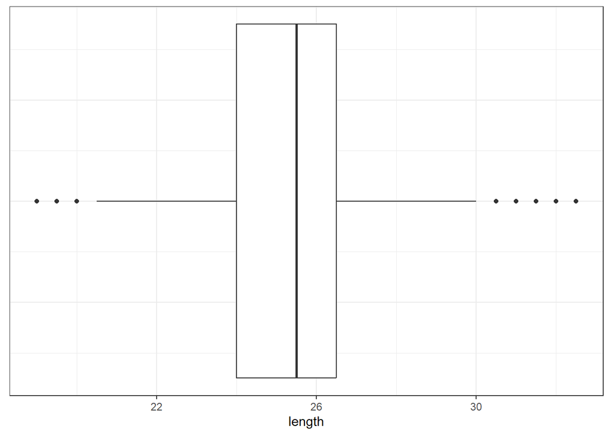

```
##    Min. 1st Qu.  Median    Mean 3rd Qu.    Max.
##    19.0    24.0    25.5    25.3    26.5    32.5
```

Niestety dane w zbiorze z pewnością nie są chronologiczne, dlatego nie można zaprezentować rozmiaru śledzi w kolejnych latach. Można natomiast prześledzić (pun not intended), jak zmienia się długość śledzia na przestrzeni roku, co pokazuje poniższa animacja:

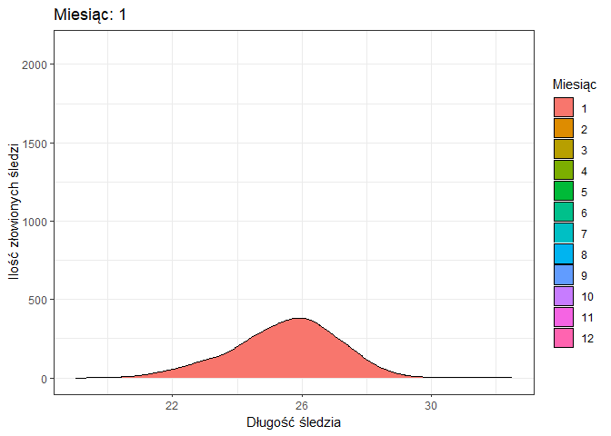

```r
p <- df %>%
  ggplot(aes(x = length, fill = factor(xmonth))) +
  geom_density(aes(y = after_stat(count)), adjust=1.5) +
  transition_time(xmonth) +
  labs(title = "Miesiąc: {frame_time}", y = "Ilość złowionych śledzi",
       x = "Długość śledzia", fill = "Miesiąc") +
  theme_bw()
animate(p)
```

## 6.2 Dostępność planktonu

W tym podpunkcie przedstawiono na wykresach wszystkie parametry dotyczące dostępności planktonu

```r
columnNames = c("cfin1", "cfin2", "chel1", "chel2", "lcop1", "lcop2")

kable(summary(data.frame(df[columnNames]))) %>%
  kable_styling("striped")
```

|  | cfin1 | cfin2 | chel1 | chel2 | lcop1 | lcop2 |
| --- | --- | --- | --- | --- | --- | --- |
|  | Min. : 0.0000 | Min. : 0.0000 | Min. : 0.000 | Min. : 5.238 | Min. : 0.3074 | Min. : 7.849 |
|  | 1st Qu.: 0.0000 | 1st Qu.: 0.2778 | 1st Qu.: 2.469 | 1st Qu.:13.427 | 1st Qu.: 2.5479 | 1st Qu.:17.808 |
|  | Median : 0.1111 | Median : 0.7012 | Median : 5.750 | Median :21.435 | Median : 7.0000 | Median :24.859 |
|  | Mean : 0.4451 | Mean : 2.0261 | Mean : 9.995 | Mean :21.219 | Mean : 12.7860 | Mean :28.423 |
|  | 3rd Qu.: 0.3333 | 3rd Qu.: 1.7936 | 3rd Qu.:11.500 | 3rd Qu.:27.193 | 3rd Qu.: 21.2315 | 3rd Qu.:37.232 |
|  | Max. :37.6667 | Max. :19.3958 | Max. :75.000 | Max. :57.706 | Max. :115.5833 | Max. :68.736 |

Warto odsiać dla każdego z parametrów maksymalne wartości, które wyglądają na outliery.

```r
df <- df %>% filter(cfin1 < quantile(df$cfin1, 0.975) |
                    cfin2 < quantile(df$cfin2, 0.975) |
                    chel1 < quantile(df$chel1, 0.975))
```

```r
dim(df)
```

```
## [1] 52582    16
```

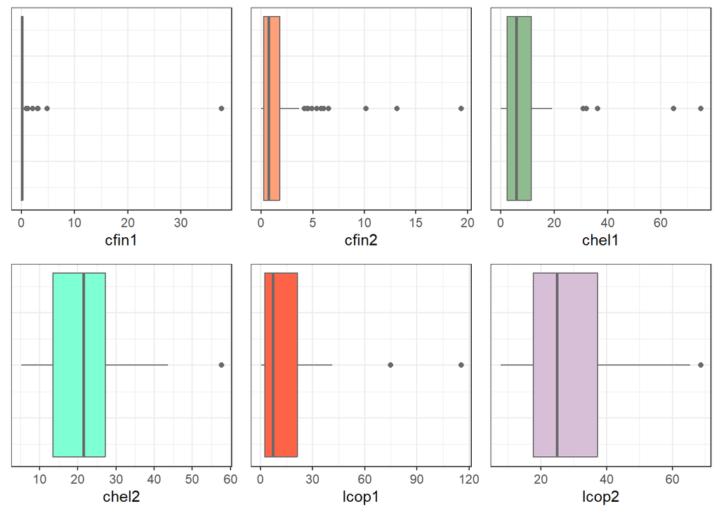

```r
drawBoxplot <- function(column, label, fillColor, shapeColor){
  p <- ggplot(df, aes(y=column)) +
    geom_boxplot(width=0.7, fill=fillColor, color=shapeColor) +
    coord_flip() +
    labs(y=label) + theme_bw() +
    theme(axis.ticks.y=element_blank()) +
    theme(axis.text.y=element_blank())
  p
}

p1<-drawBoxplot(df$cfin1, "cfin1", "skyblue", "dimgray")
p2<-drawBoxplot(df$cfin2, "cfin2", "lightsalmon", "dimgray")
p3<-drawBoxplot(df$chel1, "chel1", "darkseagreen", "dimgray")
p4<-drawBoxplot(df$chel2, "chel2", "aquamarine", "dimgray")
p5<-drawBoxplot(df$lcop1, "lcop1", "tomato", "dimgray")
p6<-drawBoxplot(df$lcop2, "lcop2", "thistle", "dimgray")

ggarrange(p1, p2, p3, p4, p5, p6)
```

## 6.3 Roczny narybek

```r
kable(summary(data.frame(df$recr))) %>%
  kable_styling("striped")
```

|  | df.recr |
| --- | --- |
|  | Min. : 140515 |
|  | 1st Qu.: 360061 |
|  | Median : 421391 |
|  | Mean : 520367 |
|  | 3rd Qu.: 724151 |
|  | Max. :1565890 |

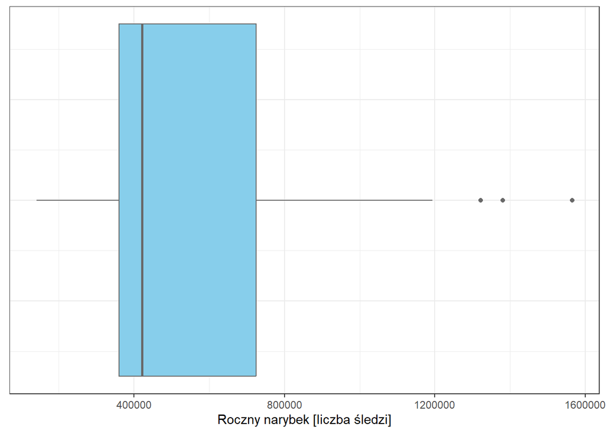

```r
drawBoxplot(df$recr, "Roczny narybek [liczba śledzi]", "skyblue", "dimgray")
```

## 6.4 Roczne natężenie połowów w regionie

```r
kable(summary(data.frame(df$cumf))) %>%
  kable_styling("striped")
```

|  | df.cumf |
| --- | --- |
|  | Min. :0.06833 |
|  | 1st Qu.:0.14809 |
|  | Median :0.23191 |
|  | Mean :0.22981 |
|  | 3rd Qu.:0.29803 |
|  | Max. :0.39801 |

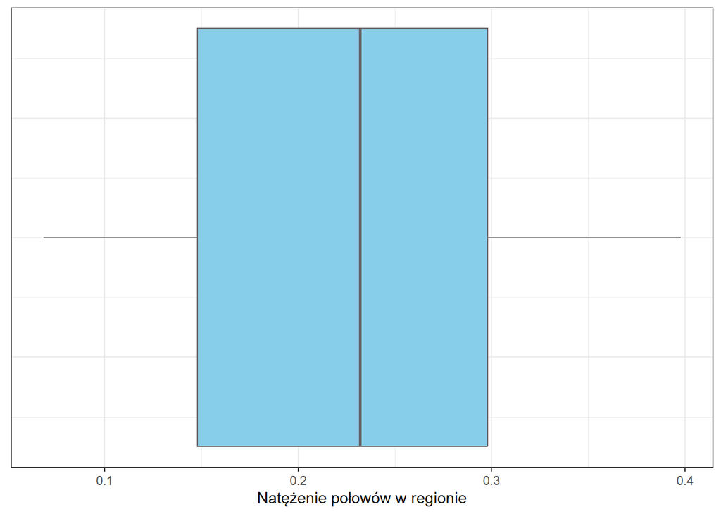

```r
drawBoxplot(df$cumf, "Natężenie połowów w regionie", "skyblue", "dimgray")
```

## 6.5 Łączna liczba ryb złowionych w ramach połowu

```r
kable(summary(data.frame(df$totaln))) %>%
  kable_styling("striped")
```

|  | df.totaln |
| --- | --- |
|  | Min. : 144137 |
|  | 1st Qu.: 306068 |
|  | Median : 539558 |
|  | Mean : 514973 |
|  | 3rd Qu.: 730351 |
|  | Max. :1015595 |

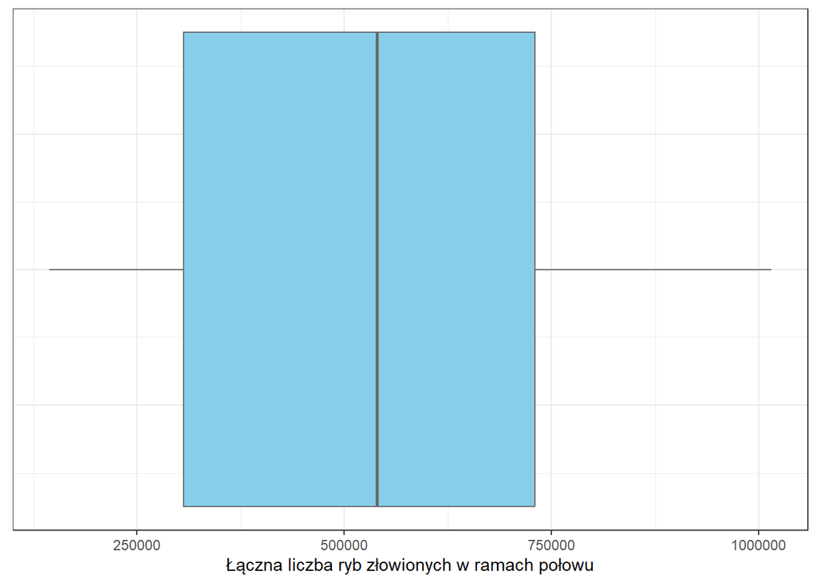

```r
drawBoxplot(df$totaln, "Łączna liczba ryb złowionych w ramach połowu", "skyblue", "dimgray")
```

## 6.6 Temperatura przy powierzchni wody

```r
kable(summary(data.frame(df$sst))) %>%
  kable_styling("striped")
```

|  | df.sst |
| --- | --- |
|  | Min. :12.77 |
|  | 1st Qu.:13.60 |
|  | Median :13.86 |
|  | Mean :13.87 |
|  | 3rd Qu.:14.16 |
|  | Max. :14.73 |

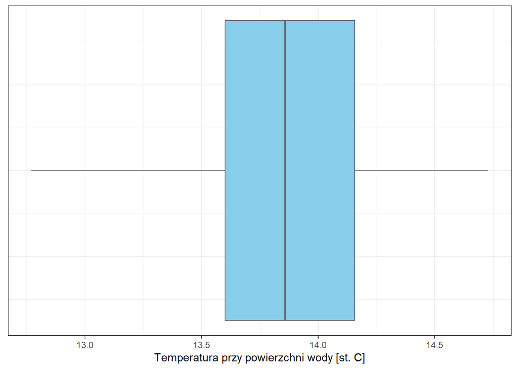

```r
drawBoxplot(df$sst, "Temperatura przy powierzchni wody [st. C]", "skyblue", "dimgray")
```

## 6.7 Poziom zasolenia wody

```r
kable(summary(data.frame(df$sal))) %>%
  kable_styling("striped")
```

|  | df.sal |
| --- | --- |
|  | Min. :35.40 |
|  | 1st Qu.:35.51 |
|  | Median :35.51 |
|  | Mean :35.51 |
|  | 3rd Qu.:35.52 |
|  | Max. :35.61 |

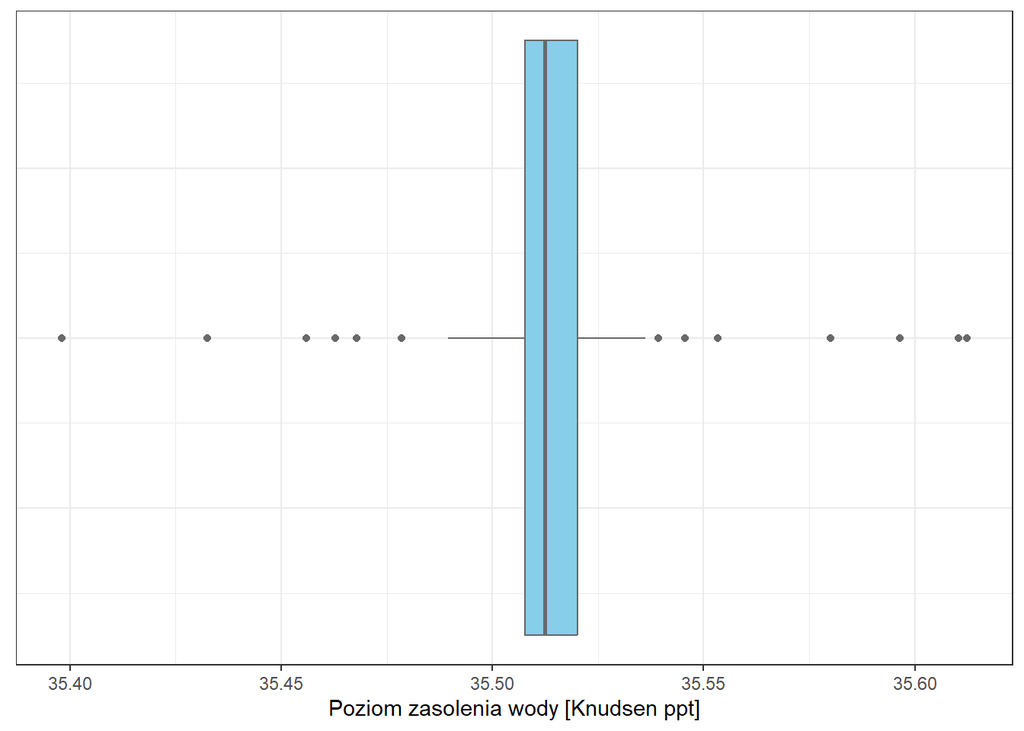

```r
drawBoxplot(df$sal, "Poziom zasolenia wody [Knudsen ppt]", "skyblue", "dimgray")
```

## 6.8 Oscylacja północnoatlantycka

```r
kable(summary(data.frame(df$nao))) %>%
  kable_styling("striped")
```

|  | df.nao |
| --- | --- |
|  | Min. :-4.89000 |
|  | 1st Qu.:-1.89000 |
|  | Median : 0.20000 |
|  | Mean :-0.09236 |
|  | 3rd Qu.: 1.63000 |
|  | Max. : 5.08000 |

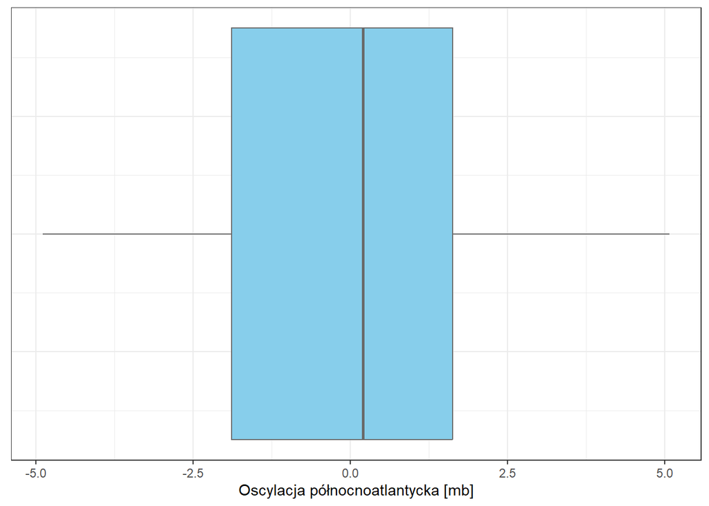

```r
drawBoxplot(df$nao, "Oscylacja północnoatlantycka [mb]", "skyblue", "dimgray")
```

# 7 Analiza korelacji między atrybutami

Na poniższym wykresie przedstawiono korelację między poszczególnymi atrybutami występującymi w zbiorze.

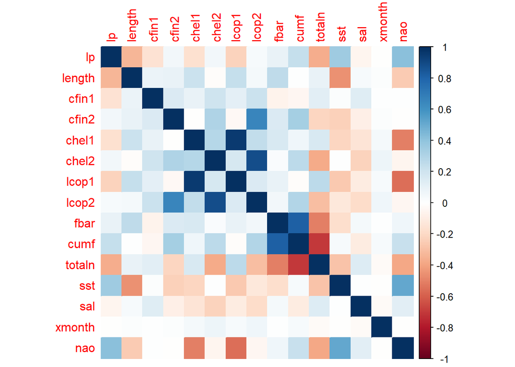

```r
new_df <- df %>% select(-recr)
corrplot(cor(new_df), method="color")
```

Z powyższego wykresu można wysunąć następujące wnioski:

- miesiąc połowu jest bardzo słabo skorelowany z długością śledzia
- sst czyli temperatura przy powierzchni jest dość silnie skorelowana z długością śledzia
- mamy następujące pary silnie skorelowanych parametrów: chel1 i lcop1, chel2 i lcop2

```r
df <- df %>% select(c(-lcop1, lcop2, recr, totaln, lp))
df
```

```
## # A tibble: 52,582 × 15
## # Rowwise:
##       lp length  cfin1 cfin2 chel1 chel2 lcop2  fbar   recr  cumf  totaln   sst
##    <int>  <dbl>  <dbl> <dbl> <dbl> <dbl> <dbl> <dbl>  <dbl> <dbl>   <dbl> <dbl>
##  1     0   23   0.0278 0.278  2.47  21.4  26.4 0.356 482831 0.306 267381.  14.3
##  2     1   22.5 0.0278 0.278  2.47  21.4  26.4 0.356 482831 0.306 267381.  14.3
##  3     2   25   0.0278 0.278  2.47  21.4  26.4 0.356 482831 0.306 267381.  14.3
##  4     3   25.5 0.0278 0.278  2.47  21.4  26.4 0.356 482831 0.306 267381.  14.3
##  5     4   24   0.0278 0.278  2.47  21.4  26.4 0.356 482831 0.306 267381.  14.3
##  6     5   22   0.0278 0.278  2.47  21.4  26.4 0.356 482831 0.306 267381.  14.3
##  7     6   24   0.0278 0.278  2.47  21.4  26.4 0.356 482831 0.306 267381.  14.3
##  8     7   23.5 0.0278 0.278  2.47  21.4  26.4 0.356 482831 0.306 267381.  14.3
##  9     8   22.5 0.0278 0.278  2.47  21.4  26.4 0.356 482831 0.306 267381.  14.3
## 10     9   22.5 0.0278 0.278  2.47  21.4  26.4 0.356 482831 0.306 267381.  14.3
## # … with 52,572 more rows, and 3 more variables: sal <dbl>, xmonth <int>,
## #   nao <dbl>
```

# 8 Budowa regresorów

```r
inTraining <- createDataPartition(
  y = df$length,
  p = .8,
  list = FALSE
)
training <- df[inTraining, ]
testing <- df[-inTraining, ]

ctrl <- trainControl(
    method = "repeatedcv",
    number = 2,
    repeats = 5,
    allowParallel = TRUE,
    verboseIter = FALSE
)
```

Do uczenia modeli zostaną wykorzystane algorytm zwykłej regresji liniowej oraz random forest.

## 8.1 Regresja liniowa

```r
fitTune_lm <- train(
  length ~ .,
  data = training,
  method = "lm",
  metric = "RMSE",
  trControl = ctrl,
  preProc = c("center", "scale"),
  tuneGrid = expand.grid(intercept=c(TRUE, FALSE))
)
fitTune_lm
```

```
## Linear Regression
##
## 42067 samples
##    14 predictor
##
## Pre-processing: centered (14), scaled (14)
## Resampling: Cross-Validated (2 fold, repeated 5 times)
## Summary of sample sizes: 21034, 21033, 21033, 21034, 21033, 21034, ...
## Resampling results across tuning parameters:
##
##   intercept  RMSE       Rsquared   MAE
##   FALSE      25.338640  0.3528116  25.303785
##    TRUE       1.328606  0.3528116   1.049597
##
## RMSE was used to select the optimal model using the smallest value.
## The final value used for the model was intercept = TRUE.
```

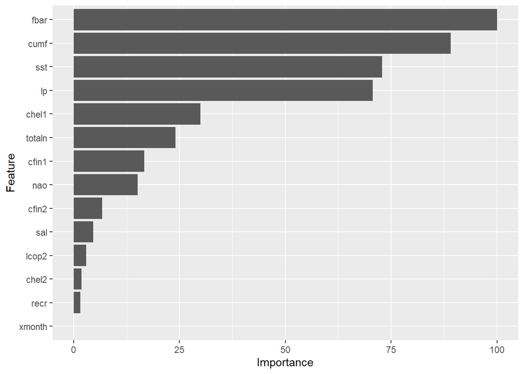

```r
ggplot(varImp(fitTune_lm))
```